# mw2931_guns_exercise

Michael Weisner

2/10/2019

```r
library(dplyr)
library(tidyverse)
```

## Datasource 1: Gunsales - NYTimes

```r
library(gunsales)
gun_sales <- analysis()
```

```
## [1] "Increase in monthly gun sales in Missouri = 8773.09"
```

```r
str(gun_sales[,1:12])
```

```
## 'data.frame':    194 obs. of  12 variables:
##  $ year                      : num  2000 2000 2000 2000 2000 2000 2000 2000 2000 2000 ...
##  $ month                     : num  1 2 3 4 5 6 7 8 9 10 ...
##  $ guns_total                : num  574951 649111 664622 552965 467712 ...
##  $ guns_total_seas           : num  655202 658994 657119 659742 647645 ...
##  $ guns_total_per_1000       : num  2.33 2.35 2.34 2.34 2.3 ...
##  $ guns_total_per_1000_scaled: num  2.33 2.35 2.34 2.35 2.31 ...
##  $ handgun                   : num  185626 186960 187639 188129 181971 ...
##  $ longgun                   : num  393146 396785 393996 396675 391434 ...
##  $ other                     : num  0 0 0 0 0 0 0 0 0 0 ...
##  $ multiple                  : num  8003 8021 8271 8288 8729 ...
##  $ longgun_share             : num  0.675 0.675 0.673 0.673 0.677 ...
##  $ handgun_share             : num  0.319 0.318 0.32 0.319 0.315 ...
```

## Datasource 2: Gun ownership survey data - Washington Post

```r
library(XML)
library(dplyr)
gun_ownership_url = 'http://www.washingtonpost.com/wp-srv/health/interactives/guns/ownership.html'
gun_ownership = readHTMLTable(gun_ownership_url, header = TRUE, which = 1)
gun_ownership = gun_ownership[-1, ]
parse_num = function (x) as.numeric(sub(',', '', x))
gun_ownership = select(gun_ownership, State = 1, Total = 2, Yes = 3,
                       `Yes %` = 4, No = 5, `No %` = 6) %>%
                        mutate_each(funs(parse_num), -State)
```

```
## `mutate_each()` is deprecated.
## Use `mutate_all()`, `mutate_at()` or `mutate_if()` instead.
## To map `funs` over a selection of variables, use `mutate_at()`
```

```r
head(gun_ownership)
```

```
##              State  Total   Yes Yes %     No No %
## 1 All Participants 201881 67786  31.7 134095 68.3
## 2          Alabama   2623  1294  51.7   1329 48.3
## 3           Alaska   2716  1627  57.8   1089 42.2
## 4          Arizona   3066   989  31.1   2077 68.9
## 5         Arkansas   2780  1431  55.3   1349 44.7
## 6      California*   3897   846  21.3   3051 78.7
```

```r
gun_ownership = gun_ownership %>%
    mutate(`Child access prevention` = grepl('\\*$', State),
           State  = sub('\\*$', '', State))
# Fix D.C. name
gun_ownership[gun_ownership$State == 'The District', 'State'] = 'District of Columbia'
```

## Datasource 3: Deaths due to firearms by state - Kaiser Family Foundation

```r
# Website appears to block scraping, but allows downloading data.
# gun_deaths_url = 'http://kff.org/other/state-indicator/firearms-death-rate-per-100000/'
# gun_deaths = readHTMLTable(gun_deaths_url)
# Instead, we use the manually downloaded CSV output.
gun_deaths = read.csv("KFF_deaths_firearms.csv", skip = 3) %>%
    select(State = 1, `Deaths per 100000` = 2)
head(gun_deaths)
```

```
##           State Deaths per 100000
## 1 United States              10.3
## 2       Alabama              16.9
## 3        Alaska              19.2
## 4       Arizona              13.5
## 5      Arkansas              16.6
## 6    California               7.4
```

## Dataset 4: Gun-related deaths at the invidual level (2012-2014)

```r
library(readr)
gun_inddeaths <- read_csv("https://raw.githubusercontent.com/fivethirtyeight/guns-data/master/full_data.csv")
```

[output not shown]

```r
gun_inddeaths <- gun_inddeaths[,2:dim(gun_inddeaths)[2]]
head(gun_inddeaths)
```

```
FALSE # A tibble: 6 x 10
FALSE    year month intent  police sex     age race     hispanic place  education
FALSE   <dbl> <chr> <chr>    <dbl> <chr> <dbl> <chr>       <dbl> <chr>  <chr>
FALSE 1  2012 01    Suicide      0 M        34 Asian/P…      100 Home   BA+
FALSE 2  2012 01    Suicide      0 F        21 White         100 Street Some col…
FALSE 3  2012 01    Suicide      0 M        60 White         100 Other… BA+
FALSE 4  2012 02    Suicide      0 M        64 White         100 Home   BA+
FALSE 5  2012 02    Suicide      0 M        31 White         100 Other… HS/GED
FALSE 6  2012 02    Suicide      0 M        17 Native …      100 Home   Less tha…
```

## Does gun ownership correlate with firearm deaths in the U.S.? Does the pattern hold only in the aggregate or also by state?

### Data

I first did an innerjoin of valid cases for gun ownership and gun death datasets.

### Deaths per 100K and Percentage Owning Guns

I identified deaths per 100K people and the percentage of gun owners as state-level and relatively equivalent variables to compare.

### Exploratory Plots

I took a few stabs at this. My ideal was side-by-side bar charts with two y-axes (though this can sometimes be hard to read) to see if it’s possible to compare the trends between states’ gun ownership and deaths.

```r
gun_own_death <- as.tibble(inner_join(gun_ownership, gun_deaths, by = NULL))
```

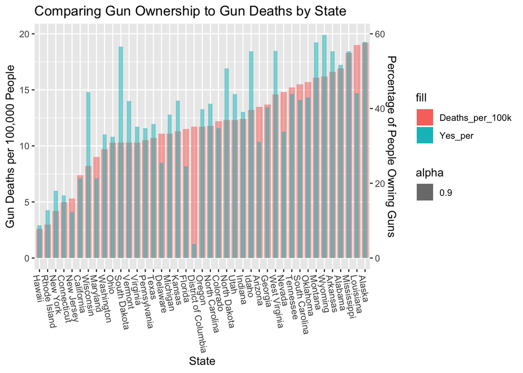

```r
gun_own_death <- rename(gun_own_death, Deaths_per_100k = `Deaths per 100000`)
gun_own_death <- rename(gun_own_death, Yes_per = `Yes %`)

ggplot(data = gun_own_death, aes(x = reorder(State, Deaths_per_100k), y = Deaths_per_100k, group = State, alpha = 0.9)) +
  geom_col(aes(y = Deaths_per_100k, fill = "Deaths_per_100k", width = 0.8), position = position_dodge2(preserve = "total")) +
  geom_col(aes(y = Yes_per/3, fill = "Yes_per", width=0.5), position = position_dodge2(preserve = "total")) +
  scale_y_continuous(sec.axis = sec_axis(~.*3, name = "Percentage of People Owning Guns")) +
  theme(axis.text.x=element_text(angle = -80, hjust = 0)) +
  xlab("State") +
  ylab("Gun Deaths per 100,000 People") +
  ggtitle("Comparing Gun Ownership to Gun Deaths by State")
```

My original attempt was to create two side-by-side bars for each state showing the level of gun deaths per 100k people and the percentage who owns guns in the state. I realized you can’t do a position dodge with two seperate geom_cols. I then attempted to make them tidy as such:

```r
library(reshape2)
gun.long<-melt(select(gun_own_death, State = State, Yes_per = Yes_per, Deaths_per_100k = Deaths_per_100k))
```

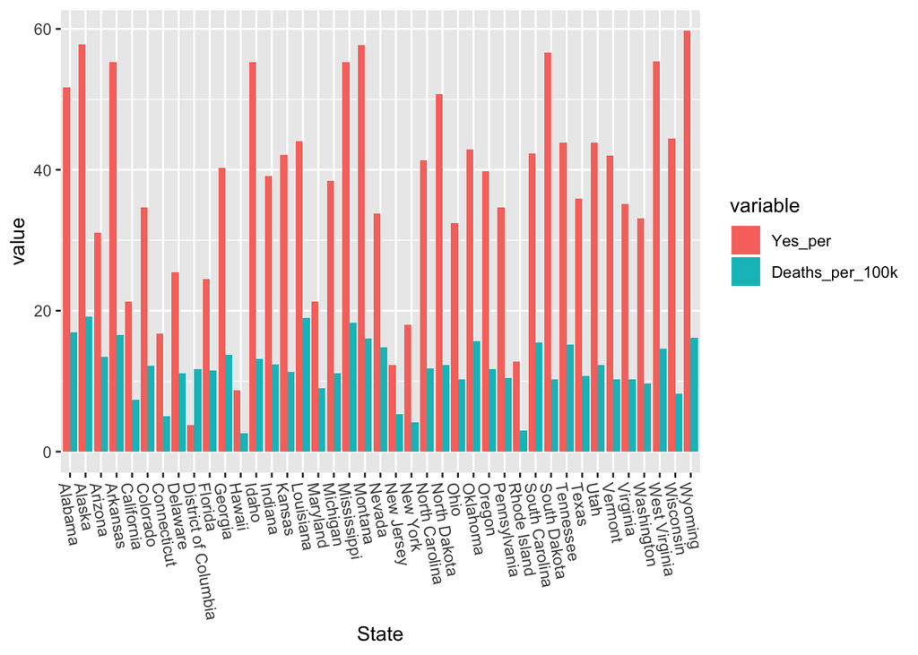

```r
ggplot(gun.long,aes(State, value, fill=variable))+
     geom_col(stat="identity",position="dodge") +
  theme(axis.text.x=element_text(angle = -80, hjust = 0))
```

Overall this was closer but it needs to have more separation and it wasn’t possible to put them on a similar axis, or have the second axis visible. I experimented more.

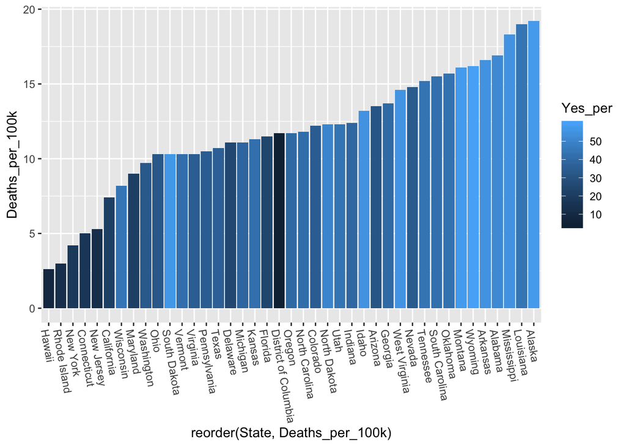

```r
ggplot(data = gun_own_death, aes(x = reorder(State, Deaths_per_100k), y = Deaths_per_100k, group = State)) +
  geom_col(aes(y= Deaths_per_100k, fill = Yes_per),
    stat = 'identity',
    position = 'dodge') +
  theme(axis.text.x=element_text(angle = -80, hjust = 0))
```

I thought the fill might be useful but it’s not quite as easily legible. It might be better to do some kind of quantile based coloring, but you can see a general trend of darker to lighter in correspondence with shorter to taller.

### Final Plots

```r
gun_own_death <- as.tibble(inner_join(gun_ownership, gun_deaths, by = NULL))
gun_own_death <- rename(gun_own_death, `Gun Deaths per 100000` = `Deaths per 100000`)
gun_own_death <- rename(gun_own_death, `Percent Owning Guns` = `Yes %`)
```

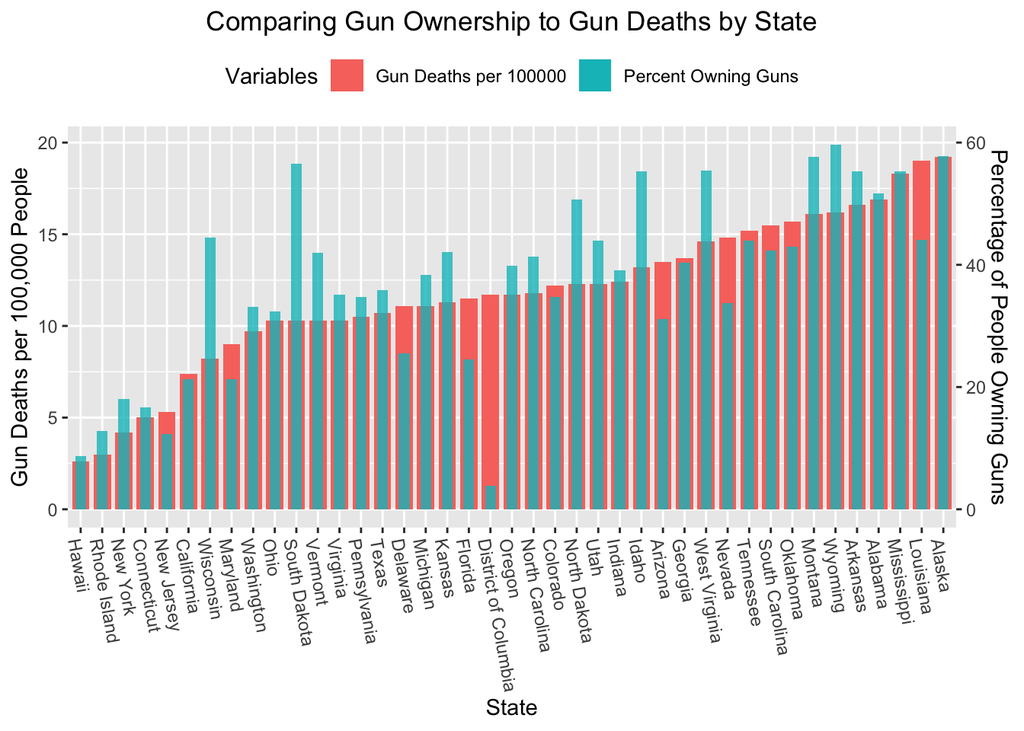

```r
ggplot(data = gun_own_death, aes(x = reorder(State, `Gun Deaths per 100000`), y = `Gun Deaths per 100000`, group = State)) +
  geom_col(aes(y = `Gun Deaths per 100000`, fill = "Gun Deaths per 100000"), width = 0.8, position = position_dodge2(preserve = "total")) +
  geom_col(aes(y = `Percent Owning Guns`/3, fill = "Percent Owning Guns"), width=0.5, alpha = 0.8, position = position_dodge2(preserve = "total")) +
  scale_y_continuous(sec.axis = sec_axis(~.*3, name = "Percentage of People Owning Guns")) +
  theme(axis.text.x=element_text(angle = -80, hjust = 0)) +
  xlab("State") +
  ylab("Gun Deaths per 100,000 People") +
  labs(fill = "Variables") +
  theme(legend.position = "top") +
  ggtitle("Comparing Gun Ownership to Gun Deaths by State") +
  theme(plot.title = element_text(hjust = 0.5))
```

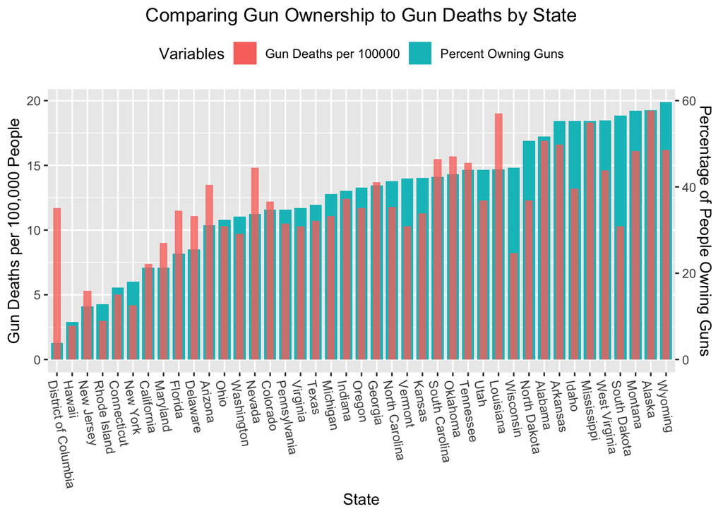

```r
ggplot(data = gun_own_death, aes(x = reorder(State, `Percent Owning Guns`), y = `Gun Deaths per 100000`, group = State)) +
  geom_col(aes(y = `Percent Owning Guns`/3, fill = "Percent Owning Guns"), width=0.8, position = position_dodge2(preserve = "total")) +
  scale_y_continuous(sec.axis = sec_axis(~.*3, name = "Percentage of People Owning Guns")) +
  geom_col(aes(y = `Gun Deaths per 100000`, fill = "Gun Deaths per 100000"), width = 0.5, alpha = 0.8) +
  theme(axis.text.x=element_text(angle = -80, hjust = 0)) +
  xlab("State") +
  ylab("Gun Deaths per 100,000 People") +
  labs(fill = "Variables") +
  theme(legend.position = "top") +
  ggtitle("Comparing Gun Ownership to Gun Deaths by State") +
  theme(plot.title = element_text(hjust = 0.5))
```

Back to my original idea, I tried two overlaid and scaled geom_col() functions. I think this was the easiest to see the general trend, but it’s a bit cluttered in design.